# Annotate Components

Jarning

2021/1/9

## 1. Init

```r
library(tidyverse)
```

```r
dir.create("tmp/step3")
```

## 2. Explore Usage matrix

```r
cells <- read.csv("../data/GSE154989_mmLungPlate_fQC_smpTable.csv")
cells.annot <- read.csv("../data/GSE154989_mmLungPlate_fQC_dZ_annot_smpTable.csv")
cells.annot <- cells.annot %>%
  left_join(cells, by = "sampleID")
head(cells.annot)
```

```
##                  sampleID clusterK12     tSNE_1     tSNE_2    phate_1
## 1 KP_30w_ND_m3_T7_P1_S302         11  53.618231 -16.560435  0.7686242
## 2 KP_30w_ND_m2_T4_P5_S331         12 -18.802622  39.078073 -0.1940938
## 3  K_12w_ND_m3_T0_P2_S272          5 -43.260232  -2.067955  0.1687666
## 4 KP_30w_ND_m2_T1_P4_S219         10   6.216744  24.974503 -0.1817356
## 5   K_2w_ND_m3_T0_P1_S245          1  -5.762314 -26.705774  0.1188655
## 6 KP_30w_ND_m1_T2_P1_S267          9  12.677095  37.489225  0.4509116
##        phate_2            plateID         mouseID        timesimple
## 1  0.482971764 KP_30w_ND_m3_T7_P1 KP_30w_ND_m3_T7      08_KP_30w_ND
## 2  0.498761000 KP_30w_ND_m2_T4_P5 KP_30w_ND_m2_T4      08_KP_30w_ND
## 3  0.218258799  K_12w_ND_m3_T0_P2     K_12w_ND_m3       04_K_12w_ND
## 4  0.172537197 KP_30w_ND_m2_T1_P4 KP_30w_ND_m2_T1      08_KP_30w_ND
## 5 -0.565761159   K_2w_ND_m3_T0_P1      K_2w_ND_m3 02_KorKP_early_ND
## 6 -0.003728375 KP_30w_ND_m1_T2_P1 KP_30w_ND_m1_T2      08_KP_30w_ND
##         typeID
## 1 08_KP_30w_ND
## 2 08_KP_30w_ND
## 3  04_K_12w_ND
## 4 08_KP_30w_ND
## 5   02_K_2w_ND
## 6 08_KP_30w_ND
```

```r
usage <- read_tsv("tmp/step2/20210110/20210110.usages.k_16.dt_0_20.consensus.normalized.txt")
head(usage)
```

```
## # A tibble: 6 x 17
##   index Usage_1 Usage_2 Usage_3 Usage_4 Usage_5 Usage_6 Usage_7 Usage_8 Usage_9
##   <chr>   <dbl>   <dbl>   <dbl>   <dbl>   <dbl>   <dbl>   <dbl>   <dbl>   <dbl>
## 1 KP_3…       0 0.00764 0.0180  0         0     0.00281 0       0        0
## 2 KP_3…       0 0       0.0695  0         0     0       0       0.175    0
## 3 K_12…       0 0.275   0       0.137     0     0       0.00830 0.0566   0.0190
## 4 KP_3…       0 0.0379  0       0.00319   0     0.415   0       0        0
## 5 K_2w…       0 0.0327  0.00274 0.111     0.745 0       0.00704 0.00307  0
## 6 KP_3…       0 0.0607  0       0.0283    0     0.150   0       0        0
## # … with 7 more variables: Usage_10 <dbl>, Usage_11 <dbl>, Usage_12 <dbl>,
## #   Usage_13 <dbl>, Usage_14 <dbl>, Usage_15 <dbl>, Usage_16 <dbl>
```

```r
cells.annot <- cells.annot %>%
  left_join(usage, by = c("sampleID"="index"))
# head(cells.annot)
```

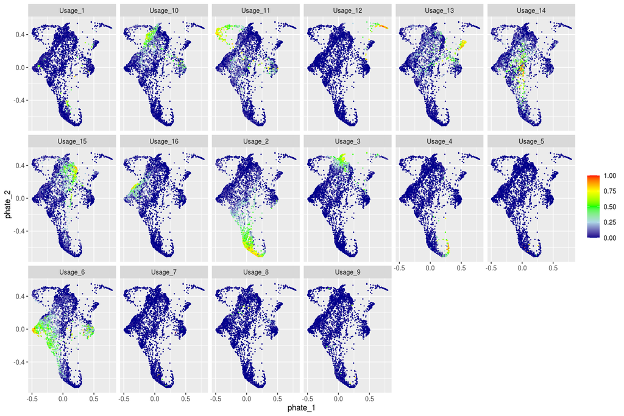

```r
K = 16 # number of programs
active.color <- c("darkblue", "lightblue", "green", "yellow", "red")

cells.annot %>%
  pivot_longer(cols = (ncol(.)-K+1):ncol(.), names_to = "program", values_to = "activity.score") %>%
  ggplot(aes(phate_1, phate_2)) +
  geom_point(aes(color = activity.score),size = 0.2) +
  scale_color_gradientn(name = NULL, colors = active.color) +
  facet_wrap(~program, ncol = 6)
```

按照肿瘤发生顺序，我们挑选出值得关注的programs

- Usage_2, AT2-like(in paper)
- Usage_14, Mixed AT1/AT2 (in paper)
- Usage_15, highly mixed (in paper)
- Usage_16, Embryonic liver-like (in paper)
- Usage_12, EMT (in paper)

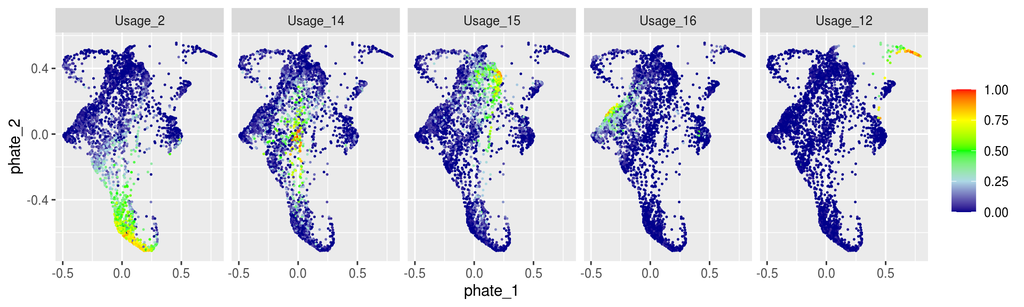

```r
selected.program <- paste0("Usage_", c(2,14,15,16,12))

cells.annot %>%
  pivot_longer(cols = (ncol(.)-K+1):ncol(.), names_to = "program", values_to = "activity.score") %>%
  filter(program %in% selected.program) %>%
  mutate(program = factor(program, levels = selected.program)) %>%
  ggplot(aes(phate_1, phate_2)) +
  geom_point(aes(color = activity.score),size = 0.2) +
  scale_color_gradientn(name = NULL, colors = active.color) +
  facet_wrap(~program, ncol = 5)
```

## 3. Geneset Analysis

```r
library(clusterProfiler)
```

```r
top.genes <- read_tsv("tmp/step2/20210110/20210110.top100_genes.k_16.dt_0_20.txt")
# head(top.genes)
```

```r
term2gene <- readRDS("../ref/genesets_all.term2gene.rds")
head(term2gene)
```

```
##                                                         ont   gene
## pw.1 PANTHER_MM_ALZHEIMER_DISEASE_AMYLOID_SECRETASE_PATHWAY  Psen1
## pw.2 PANTHER_MM_ALZHEIMER_DISEASE_AMYLOID_SECRETASE_PATHWAY  Psen2
## pw.3 PANTHER_MM_ALZHEIMER_DISEASE_AMYLOID_SECRETASE_PATHWAY  Aph1c
## pw.4 PANTHER_MM_ALZHEIMER_DISEASE_AMYLOID_SECRETASE_PATHWAY  Aph1a
## pw.5 PANTHER_MM_ALZHEIMER_DISEASE_AMYLOID_SECRETASE_PATHWAY  Bace1
## pw.6 PANTHER_MM_ALZHEIMER_DISEASE_AMYLOID_SECRETASE_PATHWAY Chrna7
```

```r
e.res <- pbapply::pblapply(top.genes, function(xx) {
  y <- enricher(xx, TERM2GENE=term2gene, minGSSize=20)
  return(as.data.frame(y))
})
names(e.res) <- names(top.genes)
```

program_14和program_15无法从富集分析结果得到明确定义。  
作者根据:

1. program_14中有AT1 marker genes: Hopx, Pdpn;
2. AT2 marker genes也在program_14 high activated cells表达;

认为program_14为“Mixed AT1/AT2 state”。可以认为是AT1和AT2的共同的祖细胞状态。

> The Mixed AT1/AT2 program was characterized by co-expression of AT1 markers, such as Hopx and Pdpn, together with AT2 markers Sftpc and Lyz2

```r
head(top.genes$program_14)
```

```
## [1] "Akap5"  "Rtkn2"  "Col4a3" "Sema3a" "Col4a4" "Hopx"
```

对于program_15，富集分析的结果显示其特征基因包含各种不同类型细胞的高表达基因，显示其为一种混乱的细胞状态，作者命名为“highly mixed program”。

> Conversely, the highly mixed program displayed features of drastically different cell types, ranging from trophoblast stem cells to chondroblasts and kidney tubular epithelium, suggesting that cells in this state are capable of exploring a broad phenotypic space.

save results

```r
library(xlsx)
```

```r
jgc <- function()
{
  gc()
  rJava::.jcall("java/lang/System", method = "gc")
}

filename <- "tmp/step3/enricher.xlsx"

for (i in seq_along(e.res)){
  jgc() ## 内存回收
  sheet.name <- sub("program", "cc", names(e.res)[i])
  write.xlsx(x = e.res[[i]], file = filename, sheetName = sheet.name, append = i>1, row.names = F)
}
```